# IODS final assignment

Zilan Wen

# Final assignment – Data analysis of dataset Student alcohol consumption

Created on 17.12.2017  
@author: Zilan Wen  
Email: zilan.wen@helsinki.fi

## Abstract

linear regression analysis, linear discriminant analysis(LDA) and Multiple correspondence analysis(MCA) were performed on the Data ‘student alcohol consumption’. The data for each analysis was adjusted according to the varibles of interest. In order to explore the relationship between students grades and other variables, `Grade`, the average of G1, G2 and G3, was regards as target variable. However G3 was used as the target for LDA analysis because G3 has a strong correlation with attributes G2 and G1. In terms of MCA, eight categorized varibles were selected including `address`, `famsize`, `Pstatus`, `Mjob`, `Fjob`, `reason`, `guardian`, `high_use`.

## 1. Description of data and its variables.

The data file `alcohol.txt` was formed by joining two dataset from the UCI Machine Learning Repository, [Student Performance Data](https://archive.ics.uci.edu/ml/datasets/Student+Performance) using the variables “school”, “sex”, “age”, “address”, “famsize”, “Pstatus”, “Medu”, “Fedu”, “Mjob”, “Fjob”, “reason”, “nursery”,“internet” as (student) identifiers. The data attributes include student grades, demographic, social and school related features. `alc_use` is the average related to weekday `Dalc` and weekend alcohol consumption `Walc`. `high_use` is a binary variable which is TRUE for students for which ‘alc_use’ is greater than 2 (and FALSE otherwise).

## 2. Research question to be explored

The questions are about to be explored as following:  
1. How do the demographic, social and school related features affect student grades.  
2. Which categorized variable has the most significant relationship with student grades. 3. How to cluster the students performance based on their grades.

## 3. Methods

### 3.1 multiple linear regression

Linear regression is an approach for modeling the relationship between a dependent variables *y* and one or more explanatory variables *X*.

In a simple case, the model includes one explanatory variable x: $y = a + bx + c$ R: lm(y ~ x).  
In multiple regression, the modle can include more than one explanatory variables: $y = a + b1x1+b2x2 + c$. R: lm(y ~ x1 + x2)

### 3.2 Linear discriminant analysis

Linear discriminant analysis is a classification (and dimension reduction) method. It finds the (linear) combination of the variables that separate the target variable classes. The target can be binary or multiclass variable.

### 3.3 Multiple correspondence analysis

The Multiple correspondence analysis (MCA) is an extension of the simple correspondence analysis for summarizing and visualizing a data table containing more than two categorical variables.MCA is generally used to analyse a data set from survey. The goal is to identify:

- A group of individuals with similar profile in their answers to the questions
- The associations between variable categories

## 4. Data analysis

### 4.1 Regression and model validation

The data wrangling is [here](https://github.com/Tianwaibian/IODS-Final/blob/master/create_alc_Grade.R)

```r
getwd()
```

```
## [1] "D:/github/IODS-Final"
```

```r
library(readr)
alc_Grade <- read_csv('alc_Grade.txt')
str(alc_Grade)
```

```
## Classes 'tbl_df', 'tbl' and 'data.frame':    382 obs. of  14 variables:
##  $ sex       : chr  "F" "F" "F" "F" ...
##  $ age       : int  18 17 15 15 16 16 16 17 15 15 ...
##  $ Medu      : int  4 1 1 4 3 4 2 4 3 3 ...
##  $ Fedu      : int  4 1 1 2 3 3 2 4 2 4 ...
##  $ traveltime: int  2 1 1 1 1 1 1 2 1 1 ...
##  $ studytime : int  2 2 2 3 2 2 2 2 2 2 ...
##  $ failures  : int  0 0 2 0 0 0 0 0 0 0 ...
##  $ famrel    : int  4 5 4 3 4 5 4 4 4 5 ...
##  $ freetime  : int  3 3 3 2 3 4 4 1 2 5 ...
##  $ goout     : int  4 3 2 2 2 2 4 4 2 1 ...
##  $ health    : int  3 3 3 5 5 5 3 1 1 5 ...
##  $ absences  : int  5 3 8 1 2 8 0 4 0 0 ...
##  $ alc_use   : num  1 1 2.5 1 1.5 1.5 1 1 1 1 ...
##  $ Grade     : num  6 7.67 10.33 14 10.67 ...
##  - attr(*, "spec")=List of 2
##   ..$ cols   :List of 14
##   .. ..$ sex       : list()
##   .. .. ..- attr(*, "class")= chr  "collector_character" "collector"
##   .. ..$ age       : list()
##   .. .. ..- attr(*, "class")= chr  "collector_integer" "collector"
##   .. ..$ Medu      : list()
##   .. .. ..- attr(*, "class")= chr  "collector_integer" "collector"
##   .. ..$ Fedu      : list()
##   .. .. ..- attr(*, "class")= chr  "collector_integer" "collector"
##   .. ..$ traveltime: list()
##   .. .. ..- attr(*, "class")= chr  "collector_integer" "collector"
##   .. ..$ studytime : list()
##   .. .. ..- attr(*, "class")= chr  "collector_integer" "collector"
##   .. ..$ failures  : list()
##   .. .. ..- attr(*, "class")= chr  "collector_integer" "collector"
##   .. ..$ famrel    : list()
##   .. .. ..- attr(*, "class")= chr  "collector_integer" "collector"
##   .. ..$ freetime  : list()
##   .. .. ..- attr(*, "class")= chr  "collector_integer" "collector"
##   .. ..$ goout     : list()
##   .. .. ..- attr(*, "class")= chr  "collector_integer" "collector"
##   .. ..$ health    : list()
##   .. .. ..- attr(*, "class")= chr  "collector_integer" "collector"
##   .. ..$ absences  : list()
##   .. .. ..- attr(*, "class")= chr  "collector_integer" "collector"
##   .. ..$ alc_use   : list()
##   .. .. ..- attr(*, "class")= chr  "collector_double" "collector"
##   .. ..$ Grade     : list()
##   .. .. ..- attr(*, "class")= chr  "collector_double" "collector"
##   ..$ default: list()
##   .. ..- attr(*, "class")= chr  "collector_guess" "collector"
##   ..- attr(*, "class")= chr "col_spec"
```

```r
dim(alc_Grade)
```

```
## [1] 382  14
```

```r
library(dplyr)
library(GGally)
```

```r
library(ggplot2)
```

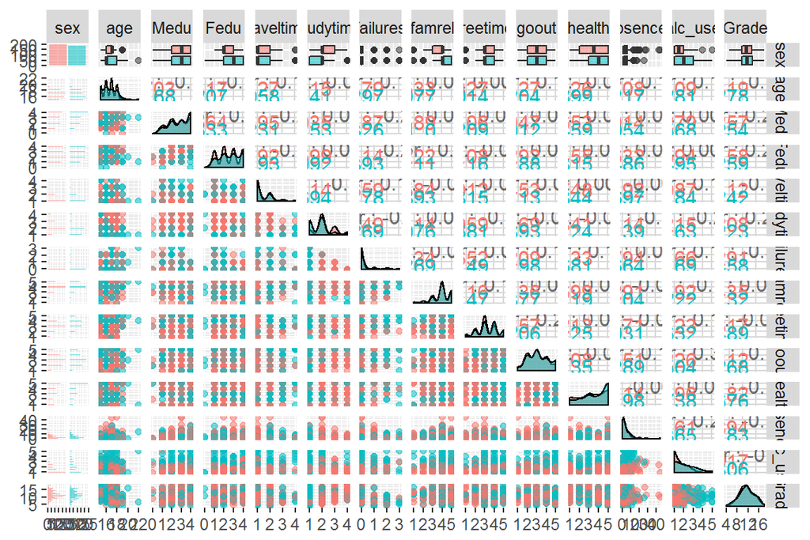

```r
p <- ggpairs(alc_Grade, mapping = aes(col=sex,alpha=0.3))
p
```

```r
summary(alc_Grade)
```

```
##      sex                 age             Medu            Fedu
##  Length:382         Min.   :15.00   Min.   :0.000   Min.   :0.000
##  Class :character   1st Qu.:16.00   1st Qu.:2.000   1st Qu.:2.000
##  Mode  :character   Median :17.00   Median :3.000   Median :3.000
##                     Mean   :16.59   Mean   :2.806   Mean   :2.565
##                     3rd Qu.:17.00   3rd Qu.:4.000   3rd Qu.:4.000
##                     Max.   :22.00   Max.   :4.000   Max.   :4.000
##    traveltime      studytime        failures          famrel
##  Min.   :1.000   Min.   :1.000   Min.   :0.0000   Min.   :1.000
##  1st Qu.:1.000   1st Qu.:1.000   1st Qu.:0.0000   1st Qu.:4.000
##  Median :1.000   Median :2.000   Median :0.0000   Median :4.000
##  Mean   :1.448   Mean   :2.037   Mean   :0.2016   Mean   :3.937
##  3rd Qu.:2.000   3rd Qu.:2.000   3rd Qu.:0.0000   3rd Qu.:5.000
##  Max.   :4.000   Max.   :4.000   Max.   :3.0000   Max.   :5.000
##     freetime        goout           health         absences
##  Min.   :1.00   Min.   :1.000   Min.   :1.000   Min.   : 0.0
##  1st Qu.:3.00   1st Qu.:2.000   1st Qu.:3.000   1st Qu.: 1.0
##  Median :3.00   Median :3.000   Median :4.000   Median : 3.0
##  Mean   :3.22   Mean   :3.113   Mean   :3.573   Mean   : 4.5
##  3rd Qu.:4.00   3rd Qu.:4.000   3rd Qu.:5.000   3rd Qu.: 6.0
##  Max.   :5.00   Max.   :5.000   Max.   :5.000   Max.   :45.0
##     alc_use          Grade
##  Min.   :1.000   Min.   : 4.000
##  1st Qu.:1.000   1st Qu.: 9.667
##  Median :1.500   Median :11.333
##  Mean   :1.889   Mean   :11.471
##  3rd Qu.:2.500   3rd Qu.:13.583
##  Max.   :5.000   Max.   :18.000
```

```r
model1 <- lm(Grade ~ Medu + Fedu + traveltime + studytime + failures + famrel + freetime + goout + health + absences + alc_use, data = alc_Grade)
summary(model1)
```

```
##
## Call:
## lm(formula = Grade ~ Medu + Fedu + traveltime + studytime + failures +
##     famrel + freetime + goout + health + absences + alc_use,
##     data = alc_Grade)
##
## Residuals:
##     Min      1Q  Median      3Q     Max
## -5.9354 -1.6811  0.0021  1.7019  7.0666
##
## Coefficients:
##             Estimate Std. Error t value Pr(>|t|)
## (Intercept) 11.79354    1.02192  11.541  < 2e-16 ***
## Medu         0.40489    0.16002   2.530   0.0118 *
## Fedu         0.06452    0.15832   0.408   0.6839
## traveltime  -0.37616    0.19435  -1.935   0.0537 .
## studytime    0.34262    0.16486   2.078   0.0384 *
## failures    -1.32634    0.24308  -5.456 8.91e-08 ***
## famrel       0.01995    0.14757   0.135   0.8926
## freetime     0.07669    0.14121   0.543   0.5874
## goout       -0.29043    0.13135  -2.211   0.0276 *
## health      -0.18005    0.09466  -1.902   0.0580 .
## absences    -0.04744    0.02456  -1.932   0.0542 .
## alc_use     -0.03951    0.15383  -0.257   0.7974
## ---
## Signif. codes:  0 '***' 0.001 '**' 0.01 '*' 0.05 '.' 0.1 ' ' 1
##
## Residual standard error: 2.525 on 370 degrees of freedom
## Multiple R-squared:  0.2286, Adjusted R-squared:  0.2056
## F-statistic: 9.967 on 11 and 370 DF,  p-value: 6.502e-16
```

The target variable `Grade` is fitted to 11 explanatory variables. According to the results of the model, `Fedu`, `famrel`, `freetime` and `alc_use` can be removed because they do not have a statistically significant relationship with the target variable, Then we rebuild the model again.

```r
model2 <- lm(Grade ~ Medu + traveltime + studytime + failures + goout + health + absences, data = alc_Grade)
summary(model2)
```

```
##
## Call:
## lm(formula = Grade ~ Medu + traveltime + studytime + failures +
##     goout + health + absences, data = alc_Grade)
##
## Residuals:
##     Min      1Q  Median      3Q     Max
## -5.8698 -1.6997  0.0262  1.6682  7.0699
##
## Coefficients:
##             Estimate Std. Error t value Pr(>|t|)
## (Intercept) 12.10261    0.79570  15.210  < 2e-16 ***
## Medu         0.44569    0.12555   3.550 0.000434 ***
## traveltime  -0.39394    0.19065  -2.066 0.039484 *
## studytime    0.33465    0.15959   2.097 0.036669 *
## failures    -1.34565    0.23775  -5.660 3.02e-08 ***
## goout       -0.28123    0.11739  -2.396 0.017080 *
## health      -0.17401    0.09289  -1.873 0.061804 .
## absences    -0.05000    0.02400  -2.084 0.037858 *
## ---
## Signif. codes:  0 '***' 0.001 '**' 0.01 '*' 0.05 '.' 0.1 ' ' 1
##
## Residual standard error: 2.513 on 374 degrees of freedom
## Multiple R-squared:  0.2275, Adjusted R-squared:  0.213
## F-statistic: 15.73 on 7 and 374 DF,  p-value: < 2.2e-16
```

- Diagnostic plots

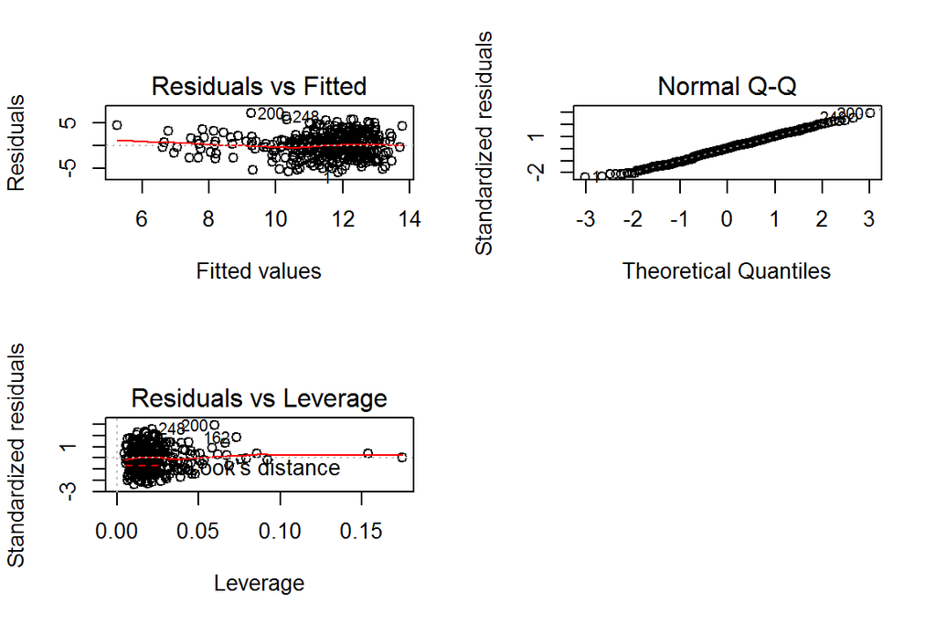

```r
par(mfrow=c(2,2))
plot(model2, which=c(1,2,5))
```

The Residuals vs Fitted values plot examines if the errors have constant variance. The graph shows a reasonable constant variance without any pattern. The Normal QQ-polt checks if the errors are normally distributed. We see from the graph a very good linear model fit, indicating a normally distributed error set. The Residuals vs Leverage confirms if there are any outliers with high leverage. From the graph, it shows that all the leverage are below 0.2, indicating good model fitting.

### 4.2 Linear discriminant analysis

The data wrangling is [here](https://github.com/Tianwaibian/IODS-Final/blob/master/create_alc_3G.R)

```r
getwd()
```

```
## [1] "D:/github/IODS-Final"
```

```r
library(readr)
alc_3G <- read_csv('alc_3G.txt')
str(alc_3G)
```

```
## Classes 'tbl_df', 'tbl' and 'data.frame':    382 obs. of  15 variables:
##  $ age       : int  18 17 15 15 16 16 16 17 15 15 ...
##  $ Medu      : int  4 1 1 4 3 4 2 4 3 3 ...
##  $ Fedu      : int  4 1 1 2 3 3 2 4 2 4 ...
##  $ traveltime: int  2 1 1 1 1 1 1 2 1 1 ...
##  $ studytime : int  2 2 2 3 2 2 2 2 2 2 ...
##  $ failures  : int  0 0 2 0 0 0 0 0 0 0 ...
##  $ famrel    : int  4 5 4 3 4 5 4 4 4 5 ...
##  $ freetime  : int  3 3 3 2 3 4 4 1 2 5 ...
##  $ goout     : int  4 3 2 2 2 2 4 4 2 1 ...
##  $ health    : int  3 3 3 5 5 5 3 1 1 5 ...
##  $ absences  : int  5 3 8 1 2 8 0 4 0 0 ...
##  $ alc_use   : num  1 1 2.5 1 1.5 1.5 1 1 1 1 ...
##  $ G1        : int  2 7 10 14 8 14 12 8 16 13 ...
##  $ G2        : int  8 8 10 14 12 14 12 9 17 14 ...
##  $ G3        : int  8 8 11 14 12 14 12 10 18 14 ...
##  - attr(*, "spec")=List of 2
##   ..$ cols   :List of 15
##   .. ..$ age       : list()
##   .. .. ..- attr(*, "class")= chr  "collector_integer" "collector"
##   .. ..$ Medu      : list()
##   .. .. ..- attr(*, "class")= chr  "collector_integer" "collector"
##   .. ..$ Fedu      : list()
##   .. .. ..- attr(*, "class")= chr  "collector_integer" "collector"
##   .. ..$ traveltime: list()
##   .. .. ..- attr(*, "class")= chr  "collector_integer" "collector"
##   .. ..$ studytime : list()
##   .. .. ..- attr(*, "class")= chr  "collector_integer" "collector"
##   .. ..$ failures  : list()
##   .. .. ..- attr(*, "class")= chr  "collector_integer" "collector"
##   .. ..$ famrel    : list()
##   .. .. ..- attr(*, "class")= chr  "collector_integer" "collector"
##   .. ..$ freetime  : list()
##   .. .. ..- attr(*, "class")= chr  "collector_integer" "collector"
##   .. ..$ goout     : list()
##   .. .. ..- attr(*, "class")= chr  "collector_integer" "collector"
##   .. ..$ health    : list()
##   .. .. ..- attr(*, "class")= chr  "collector_integer" "collector"
##   .. ..$ absences  : list()
##   .. .. ..- attr(*, "class")= chr  "collector_integer" "collector"
##   .. ..$ alc_use   : list()
##   .. .. ..- attr(*, "class")= chr  "collector_double" "collector"
##   .. ..$ G1        : list()
##   .. .. ..- attr(*, "class")= chr  "collector_integer" "collector"
##   .. ..$ G2        : list()
##   .. .. ..- attr(*, "class")= chr  "collector_integer" "collector"
##   .. ..$ G3        : list()
##   .. .. ..- attr(*, "class")= chr  "collector_integer" "collector"
##   ..$ default: list()
##   .. ..- attr(*, "class")= chr  "collector_guess" "collector"
##   ..- attr(*, "class")= chr "col_spec"
```

```r
dim(alc_3G)
```

```
## [1] 382  15
```

- `age` student’s age (numeric: from 15 to 22)
- `Medu` mother’s education
- `Fedu` father’s education
- `traveltime` home to school travel time (numeric: 1 - <15 min., 2 - 15 to 30 min., 3 - 30 min. to 1 hour, or 4 - >1 hour)
- `studytime` weekly study time (numeric: 1 - <2 hours, 2 - 2 to 5 hours, 3 - 5 to 10 hours, or 4 - >10 hours)
- `failures` number of past class failures (numeric: n if 1<=n<3, else 4)
- `famrel` quality of family relationships (numeric: from 1 - very bad to 5 - excellent)
- `freetime` free time after school (numeric: from 1 - very low to 5 - very high)
- `goout` going out with friends (numeric: from 1 - very low to 5 - very high)
- `health` current health status (numeric: from 1 - very bad to 5 - very good)
- `absences` number of school absences (numeric: from 0 to 93)
- `alc_use` the average of workday and weekend alcohol consumption
- `G1` first period grade (numeric: from 0 to 20)
- `G2` second period grade (numeric: from 0 to 20)
- `G3` final grade (numeric: from 0 to 20, output target)

```r
summary(alc_3G)
```

```
##       age             Medu            Fedu         traveltime
##  Min.   :15.00   Min.   :0.000   Min.   :0.000   Min.   :1.000
##  1st Qu.:16.00   1st Qu.:2.000   1st Qu.:2.000   1st Qu.:1.000
##  Median :17.00   Median :3.000   Median :3.000   Median :1.000
##  Mean   :16.59   Mean   :2.806   Mean   :2.565   Mean   :1.448
##  3rd Qu.:17.00   3rd Qu.:4.000   3rd Qu.:4.000   3rd Qu.:2.000
##  Max.   :22.00   Max.   :4.000   Max.   :4.000   Max.   :4.000
##    studytime        failures          famrel         freetime
##  Min.   :1.000   Min.   :0.0000   Min.   :1.000   Min.   :1.00
##  1st Qu.:1.000   1st Qu.:0.0000   1st Qu.:4.000   1st Qu.:3.00
##  Median :2.000   Median :0.0000   Median :4.000   Median :3.00
##  Mean   :2.037   Mean   :0.2016   Mean   :3.937   Mean   :3.22
##  3rd Qu.:2.000   3rd Qu.:0.0000   3rd Qu.:5.000   3rd Qu.:4.00
##  Max.   :4.000   Max.   :3.0000   Max.   :5.000   Max.   :5.00
##      goout           health         absences       alc_use
##  Min.   :1.000   Min.   :1.000   Min.   : 0.0   Min.   :1.000
##  1st Qu.:2.000   1st Qu.:3.000   1st Qu.: 1.0   1st Qu.:1.000
##  Median :3.000   Median :4.000   Median : 3.0   Median :1.500
##  Mean   :3.113   Mean   :3.573   Mean   : 4.5   Mean   :1.889
##  3rd Qu.:4.000   3rd Qu.:5.000   3rd Qu.: 6.0   3rd Qu.:2.500
##  Max.   :5.000   Max.   :5.000   Max.   :45.0   Max.   :5.000
##        G1              G2              G3
##  Min.   : 2.00   Min.   : 4.00   Min.   : 0.00
##  1st Qu.:10.00   1st Qu.:10.00   1st Qu.:10.00
##  Median :12.00   Median :12.00   Median :12.00
##  Mean   :11.49   Mean   :11.47   Mean   :11.46
##  3rd Qu.:14.00   3rd Qu.:14.00   3rd Qu.:14.00
##  Max.   :18.00   Max.   :18.00   Max.   :18.00
```

- distributions of the variables

```r
selected_variables <- subset (alc_3G, select = c('age', 'Medu', 'Fedu','traveltime', 'studytime','failures', 'famrel','freetime', 'goout', 'health', "absences", "alc_use", "G1", 'G2', "G3"))
library(tidyr)
```

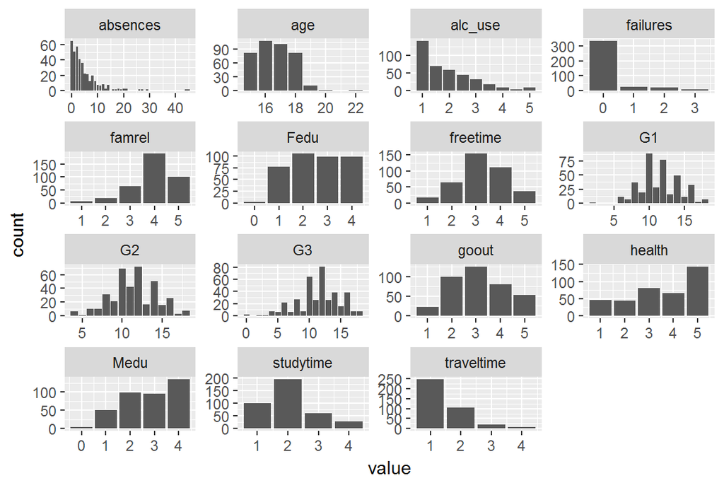

```r
library(ggplot2)
gather(selected_variables) %>% ggplot(aes(value)) + facet_wrap("key", scales = "free") + geom_bar()
```

```r
cor_matrix<-cor(alc_3G) %>% round(2)
cor_matrix
```

```
##              age  Medu  Fedu traveltime studytime failures famrel freetime
## age         1.00 -0.12 -0.13       0.11     -0.01     0.18   0.03     0.00
## Medu       -0.12  1.00  0.65      -0.20      0.06    -0.25   0.02     0.03
## Fedu       -0.13  0.65  1.00      -0.19      0.00    -0.27   0.02    -0.01
## traveltime  0.11 -0.20 -0.19       1.00     -0.10     0.14  -0.01    -0.03
## studytime  -0.01  0.06  0.00      -0.10      1.00    -0.23   0.03    -0.14
## failures    0.18 -0.25 -0.27       0.14     -0.23     1.00  -0.07     0.08
## famrel      0.03  0.02  0.02      -0.01      0.03    -0.07   1.00     0.14
## freetime    0.00  0.03 -0.01      -0.03     -0.14     0.08   0.14     1.00
## goout       0.17  0.06  0.03       0.04     -0.06     0.12   0.06     0.29
## health     -0.07 -0.04  0.02       0.00     -0.08     0.11   0.09     0.08
## absences    0.13  0.09  0.03       0.00     -0.12     0.06  -0.06    -0.03
## alc_use     0.16  0.01  0.01       0.16     -0.25     0.19  -0.12     0.18
## G1         -0.13  0.25  0.21      -0.17      0.22    -0.35   0.01    -0.03
## G2         -0.16  0.25  0.21      -0.20      0.20    -0.38   0.00    -0.05
## G3         -0.17  0.23  0.18      -0.17      0.18    -0.38   0.06    -0.04
##            goout health absences alc_use    G1    G2    G3
## age         0.17  -0.07     0.13    0.16 -0.13 -0.16 -0.17
## Medu        0.06  -0.04     0.09    0.01  0.25  0.25  0.23
## Fedu        0.03   0.02     0.03    0.01  0.21  0.21  0.18
## traveltime  0.04   0.00     0.00    0.16 -0.17 -0.20 -0.17
## studytime  -0.06  -0.08    -0.12   -0.25  0.22  0.20  0.18
## failures    0.12   0.11     0.06    0.19 -0.35 -0.38 -0.38
## famrel      0.06   0.09    -0.06   -0.12  0.01  0.00  0.06
## freetime    0.29   0.08    -0.03    0.18 -0.03 -0.05 -0.04
## goout       1.00  -0.04     0.11    0.39 -0.13 -0.17 -0.14
## health     -0.04   1.00    -0.01    0.08 -0.11 -0.14 -0.11
## absences    0.11  -0.01     1.00    0.21 -0.12 -0.14 -0.10
## alc_use     0.39   0.08     0.21    1.00 -0.18 -0.16 -0.16
## G1         -0.13  -0.11    -0.12   -0.18  1.00  0.89  0.85
## G2         -0.17  -0.14    -0.14   -0.16  0.89  1.00  0.92
## G3         -0.14  -0.11    -0.10   -0.16  0.85  0.92  1.00
```

- visualize the correlation matrix

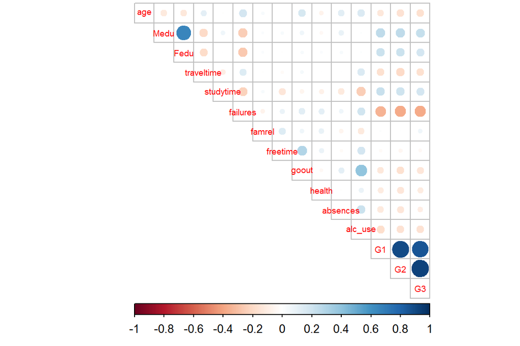

```r
library(corrplot)
corrplot(cor_matrix, method="circle", type = 'upper', cl.pos ="b", tl.pos = 'd', tl.cex = 0.6)
```

From the plot, we can see that:

- `G3` has a strong correlation with attributes `G2` and `G3`.
- Mother’s education `Medu` has a strong correlation with `Fedu`(Father’s education).
- `Failures` are negatively related to `G1`, `G2` and `G3`.
- `Fedu`, `Medu` and `studytime` have a weakly positive correlation with the grades variables.
- Standardize the dataset and print out summaries of the scaled data.

```r
alc_3G_scaled <- scale(alc_3G)
summary(alc_3G_scaled)
```

```
##       age               Medu              Fedu           traveltime
##  Min.   :-1.3519   Min.   :-2.5831   Min.   :-2.3402   Min.   :-0.6434
##  1st Qu.:-0.4997   1st Qu.:-0.7422   1st Qu.:-0.5158   1st Qu.:-0.6434
##  Median : 0.3525   Median : 0.1783   Median : 0.3964   Median :-0.6434
##  Mean   : 0.0000   Mean   : 0.0000   Mean   : 0.0000   Mean   : 0.0000
##  3rd Qu.: 0.3525   3rd Qu.: 1.0988   3rd Qu.: 1.3086   3rd Qu.: 0.7939
##  Max.   : 4.6133   Max.   : 1.0988   Max.   : 1.3086   Max.   : 3.6683
##    studytime           failures           famrel            freetime
##  Min.   :-1.23721   Min.   :-0.3458   Min.   :-3.24319   Min.   :-2.2541
##  1st Qu.:-1.23721   1st Qu.:-0.3458   1st Qu.: 0.06937   1st Qu.:-0.2233
##  Median :-0.04374   Median :-0.3458   Median : 0.06937   Median :-0.2233
##  Mean   : 0.00000   Mean   : 0.0000   Mean   : 0.00000   Mean   : 0.0000
##  3rd Qu.:-0.04374   3rd Qu.:-0.3458   3rd Qu.: 1.17356   3rd Qu.: 0.7921
##  Max.   : 2.34320   Max.   : 4.8004   Max.   : 1.17356   Max.   : 1.8075
##      goout             health           absences          alc_use
##  Min.   :-1.8897   Min.   :-1.8397   Min.   :-0.8238   Min.   :-0.9024
##  1st Qu.:-0.9952   1st Qu.:-0.4099   1st Qu.:-0.6407   1st Qu.:-0.9024
##  Median :-0.1007   Median : 0.3051   Median :-0.2746   Median :-0.3947
##  Mean   : 0.0000   Mean   : 0.0000   Mean   : 0.0000   Mean   : 0.0000
##  3rd Qu.: 0.7938   3rd Qu.: 1.0200   3rd Qu.: 0.2746   3rd Qu.: 0.6207
##  Max.   : 1.6883   Max.   : 1.0200   Max.   : 7.4139   Max.   : 3.1592
##        G1                G2                G3
##  Min.   :-3.5147   Min.   :-2.6409   Min.   :-3.4614
##  1st Qu.:-0.5517   1st Qu.:-0.5185   1st Qu.:-0.4405
##  Median : 0.1891   Median : 0.1889   Median : 0.1637
##  Mean   : 0.0000   Mean   : 0.0000   Mean   : 0.0000
##  3rd Qu.: 0.9298   3rd Qu.: 0.8963   3rd Qu.: 0.7679
##  Max.   : 2.4113   Max.   : 2.3112   Max.   : 1.9763
```

```r
class(alc_3G_scaled)
```

```
## [1] "matrix"
```

```r
alc_3G_scaled <- as.data.frame(alc_3G_scaled)
summary(alc_3G_scaled)
```

```
##       age               Medu              Fedu           traveltime
##  Min.   :-1.3519   Min.   :-2.5831   Min.   :-2.3402   Min.   :-0.6434
##  1st Qu.:-0.4997   1st Qu.:-0.7422   1st Qu.:-0.5158   1st Qu.:-0.6434
##  Median : 0.3525   Median : 0.1783   Median : 0.3964   Median :-0.6434
##  Mean   : 0.0000   Mean   : 0.0000   Mean   : 0.0000   Mean   : 0.0000
##  3rd Qu.: 0.3525   3rd Qu.: 1.0988   3rd Qu.: 1.3086   3rd Qu.: 0.7939
##  Max.   : 4.6133   Max.   : 1.0988   Max.   : 1.3086   Max.   : 3.6683
##    studytime           failures           famrel            freetime
##  Min.   :-1.23721   Min.   :-0.3458   Min.   :-3.24319   Min.   :-2.2541
##  1st Qu.:-1.23721   1st Qu.:-0.3458   1st Qu.: 0.06937   1st Qu.:-0.2233
##  Median :-0.04374   Median :-0.3458   Median : 0.06937   Median :-0.2233
##  Mean   : 0.00000   Mean   : 0.0000   Mean   : 0.00000   Mean   : 0.0000
##  3rd Qu.:-0.04374   3rd Qu.:-0.3458   3rd Qu.: 1.17356   3rd Qu.: 0.7921
##  Max.   : 2.34320   Max.   : 4.8004   Max.   : 1.17356   Max.   : 1.8075
##      goout             health           absences          alc_use
##  Min.   :-1.8897   Min.   :-1.8397   Min.   :-0.8238   Min.   :-0.9024
##  1st Qu.:-0.9952   1st Qu.:-0.4099   1st Qu.:-0.6407   1st Qu.:-0.9024
##  Median :-0.1007   Median : 0.3051   Median :-0.2746   Median :-0.3947
##  Mean   : 0.0000   Mean   : 0.0000   Mean   : 0.0000   Mean   : 0.0000
##  3rd Qu.: 0.7938   3rd Qu.: 1.0200   3rd Qu.: 0.2746   3rd Qu.: 0.6207
##  Max.   : 1.6883   Max.   : 1.0200   Max.   : 7.4139   Max.   : 3.1592
##        G1                G2                G3
##  Min.   :-3.5147   Min.   :-2.6409   Min.   :-3.4614
##  1st Qu.:-0.5517   1st Qu.:-0.5185   1st Qu.:-0.4405
##  Median : 0.1891   Median : 0.1889   Median : 0.1637
##  Mean   : 0.0000   Mean   : 0.0000   Mean   : 0.0000
##  3rd Qu.: 0.9298   3rd Qu.: 0.8963   3rd Qu.: 0.7679
##  Max.   : 2.4113   Max.   : 2.3112   Max.   : 1.9763
```

```r
summary(alc_3G_scaled$G3)
```

```
##    Min. 1st Qu.  Median    Mean 3rd Qu.    Max.
## -3.4614 -0.4405  0.1637  0.0000  0.7679  1.9763
```

```r
bins <- quantile(alc_3G_scaled$G3) %>% round(4)
bins
```

```
##      0%     25%     50%     75%    100%
## -3.4614 -0.4405  0.1637  0.7679  1.9763
```

- create a categorical variable ‘G3’

```r
Grade3 <- cut(alc_3G_scaled$G3, breaks = bins, include.lowest = TRUE, label = c('low', 'med_low', 'med_high', 'high'))
table(Grade3)
```

```
## Grade3
##      low  med_low med_high     high
##       77       90      145       68
```

- train sets

```r
alc_3G_scaled <- dplyr::select(alc_3G_scaled, -G3)
alc_3G_scaled <- data.frame(alc_3G_scaled, Grade3)
n <- nrow(alc_3G_scaled)
n
```

```
## [1] 382
```

```r
ind <- sample(n,  size = n * 0.8)
train <- alc_3G_scaled[ind,]
```

- linear discriminant analysis
- linear discriminant analysis on the train set

```r
library(MASS)
lda.fit <- lda(Grade3 ~ ., data = train)
lda.fit
```

```
## Call:
## lda(Grade3 ~ ., data = train)
##
## Prior probabilities of groups:
##       low   med_low  med_high      high
## 0.2178218 0.2310231 0.3762376 0.1749175
##
## Group means:
##                   age        Medu        Fedu traveltime   studytime
## low       0.158793854 -0.22614234 -0.17027031  0.2494536 -0.11607118
## med_low   0.035948078 -0.25562983 -0.12485731  0.1779043 -0.11193795
## med_high -0.163319537 -0.02354697  0.09233528 -0.1138599 -0.08561582
## high     -0.001262729  0.40409437  0.27592449 -0.2637177  0.42914432
##            failures      famrel    freetime       goout      health
## low       0.4859317 -0.06446789 -0.05404849  0.22458595  0.16423858
## med_low   0.1198335  0.14824361 -0.06371899 -0.03679743 -0.03197597
## med_high -0.2404413 -0.08560067 -0.06295553 -0.14777072  0.12946205
## high     -0.3134064  0.19437544 -0.10833103 -0.18507907 -0.35590339
##             absences     alc_use         G1         G2
## low       0.04437801  0.04373862 -1.0567339 -1.2420752
## med_low   0.44980286  0.23627141 -0.5358074 -0.5084421
## med_high -0.17021304  0.09070348  0.2345488  0.3223221
## high     -0.18824023 -0.39473503  1.4539215  1.4035753
##
## Coefficients of linear discriminants:
##                     LD1         LD2         LD3
## age         0.144791489  0.25408566 -0.02095212
## Medu        0.096358895  0.45697726 -0.14628192
## Fedu       -0.125478961 -0.11546112  0.00801206
## traveltime  0.018731586  0.08865146  0.19090792
## studytime  -0.052056818  0.28725806  0.19070801
## failures    0.095828057  0.58261556  0.08922434
## famrel      0.168039474  0.08373964  0.52927940
## freetime    0.006820924  0.01222532  0.05460646
## goout      -0.026178751  0.31139867 -0.27321866
## health     -0.025543057 -0.23942186 -0.45359030
## absences   -0.036681751 -0.03664831  0.74242431
## alc_use    -0.005813833 -0.51638439  0.21021282
## G1          0.746519218  1.04750735 -0.29366456
## G2          1.689591325 -0.99768219  0.36931386
##
## Proportion of trace:
##    LD1    LD2    LD3
## 0.9509 0.0314 0.0177
```

```r
lda.arrows <- function(x, myscale = 1, arrow_heads = 0.1, color = "red", tex = 0.75, choices = c(1,2)){
  heads <- coef(x)
  arrows(x0 = 0, y0 = 0,
         x1 = myscale * heads[,choices[1]],
         y1 = myscale * heads[,choices[2]], col=color, length = arrow_heads)
  text(myscale * heads[,choices], labels = row.names(heads),
       cex = tex, col=color, pos=3)
}
lda.arrows
```

```
## function(x, myscale = 1, arrow_heads = 0.1, color = "red", tex = 0.75, choices = c(1,2)){
##   heads <- coef(x)
##   arrows(x0 = 0, y0 = 0,
##          x1 = myscale * heads[,choices[1]],
##          y1 = myscale * heads[,choices[2]], col=color, length = arrow_heads)
##   text(myscale * heads[,choices], labels = row.names(heads),
##        cex = tex, col=color, pos=3)
## }
```

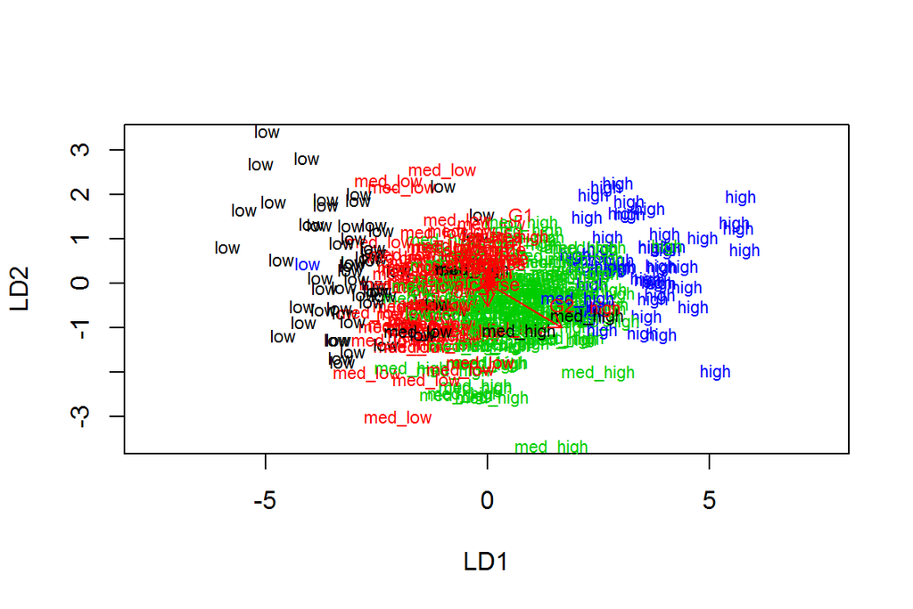

```r
classes <- as.numeric(train$Grade3)
plot(lda.fit, dimen = 2, col = classes, pch = classes)
lda.arrows(lda.fit, myscale = 1)
```

- Predict LDA

```r
test <- alc_3G_scaled[-ind,]
correct_classes <- test$Grade3
test <- dplyr::select(test, -Grade3)
lda.pred=predict(lda.fit,newdata=test)
table(correct=correct_classes,predicted=lda.pred$class) %>% addmargins
```

```
##           predicted
## correct    low med_low med_high high Sum
##   low        7       3        1    0  11
##   med_low    7       8        5    0  20
##   med_high   0       4       25    2  31
##   high       0       0        1   14  15
##   Sum       14      15       32   16  77
```

From the cross table we can see that the model could give relatively good predictions of the G3.

### 4.3 MCA

The data `Alc_MCA` is for MCA analysis.The data wrangling script is in the file named `Alc_MCA.R`. The data wrangling is [here](https://github.com/Tianwaibian/IODS-Final/blob/master/alc_MCA.R)

```r
library(readr)
Alc_MCA <- read.csv('Alc_MCA.txt')
summary(Alc_MCA)
```

```
##  address famsize   Pstatus       Mjob           Fjob            reason
##  R: 81   GT3:278   A: 38   at_home : 53   at_home : 16   course    :140
##  U:301   LE3:104   T:344   health  : 33   health  : 17   home      :110
##                            other   :138   other   :211   other     : 34
##                            services: 96   services:107   reputation: 98
##                            teacher : 62   teacher : 31
##    guardian    high_use
##  father: 91   Mode :logical
##  mother:275   FALSE:268
##  other : 16   TRUE :114
##
##
```

```r
str(Alc_MCA)
```

```
## 'data.frame':    382 obs. of  8 variables:
##  $ address : Factor w/ 2 levels "R","U": 2 2 2 2 2 2 2 2 2 2 ...
##  $ famsize : Factor w/ 2 levels "GT3","LE3": 1 1 2 1 1 2 2 1 2 1 ...
##  $ Pstatus : Factor w/ 2 levels "A","T": 1 2 2 2 2 2 2 1 1 2 ...
##  $ Mjob    : Factor w/ 5 levels "at_home","health",..: 1 1 1 2 3 4 3 3 4 3 ...
##  $ Fjob    : Factor w/ 5 levels "at_home","health",..: 5 3 3 4 3 3 3 5 3 3 ...
##  $ reason  : Factor w/ 4 levels "course","home",..: 1 1 3 2 2 4 2 2 2 2 ...
##  $ guardian: Factor w/ 3 levels "father","mother",..: 2 1 2 2 1 2 2 2 2 2 ...
##  $ high_use: logi  FALSE FALSE TRUE FALSE FALSE FALSE ...
```

- visualize the dataset

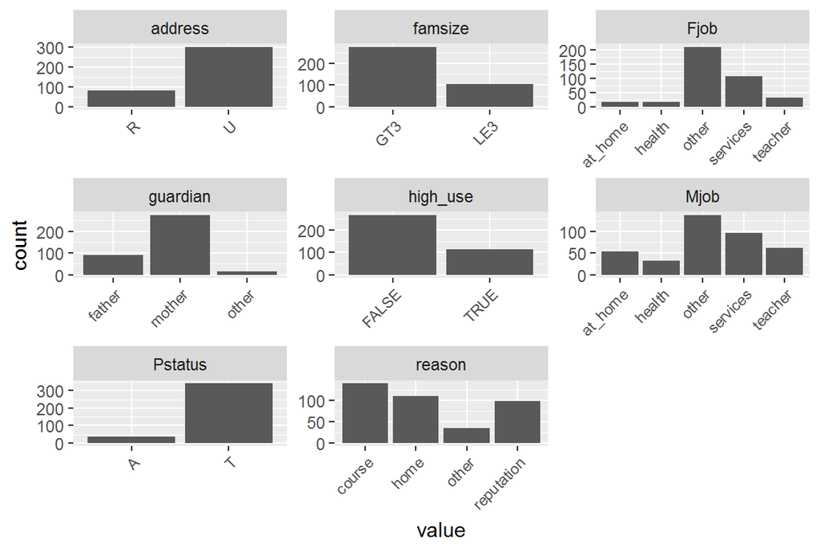

```r
library(tidyr)
library(ggplot2)
gather(Alc_MCA) %>% ggplot(aes(value)) + facet_wrap("key", scales = "free") + geom_bar() + theme(axis.text.x = element_text(angle = 45, hjust = 1, size = 8))
```

```r
library(FactoMineR)
```

```r
library(ggplot2)
library(dplyr)
library(tidyr)
alc_mca <- MCA(Alc_MCA, graph = FALSE)
summary(alc_mca)
```

```
##
## Call:
## MCA(X = Alc_MCA, graph = FALSE)
##
##
## Eigenvalues
##                        Dim.1   Dim.2   Dim.3   Dim.4   Dim.5   Dim.6
## Variance               0.187   0.181   0.165   0.156   0.151   0.145
## % of var.              8.821   8.506   7.761   7.364   7.101   6.835
## Cumulative % of var.   8.821  17.326  25.088  32.452  39.552  46.387
##                        Dim.7   Dim.8   Dim.9  Dim.10  Dim.11  Dim.12
## Variance               0.136   0.127   0.122   0.118   0.112   0.100
## % of var.              6.423   5.973   5.738   5.565   5.287   4.713
## Cumulative % of var.  52.810  58.783  64.521  70.086  75.373  80.086
##                       Dim.13  Dim.14  Dim.15  Dim.16  Dim.17
## Variance               0.097   0.093   0.087   0.083   0.064
## % of var.              4.545   4.389   4.076   3.897   3.007
## Cumulative % of var.  84.631  89.021  93.096  96.993 100.000
##
## Individuals (the 10 first)
##                  Dim.1    ctr   cos2    Dim.2    ctr   cos2    Dim.3
## 1             | -0.153  0.033  0.006 |  0.519  0.390  0.072 | -0.858
## 2             | -0.304  0.129  0.056 |  0.313  0.142  0.060 |  0.276
## 3             |  0.026  0.001  0.000 |  0.412  0.245  0.059 |  0.355
## 4             |  0.507  0.359  0.120 | -0.271  0.107  0.034 |  0.226
## 5             | -0.194  0.053  0.032 | -0.537  0.417  0.244 |  0.138
## 6             |  0.107  0.016  0.009 | -0.268  0.104  0.054 | -0.235
## 7             | -0.341  0.162  0.104 | -0.511  0.378  0.234 | -0.308
## 8             | -0.043  0.003  0.001 | -0.330  0.158  0.033 | -0.996
## 9             |  0.002  0.000  0.000 | -0.508  0.373  0.108 | -0.792
## 10            | -0.419  0.246  0.212 | -0.454  0.298  0.249 | -0.093
##                  ctr   cos2
## 1              1.168  0.198 |
## 2              0.121  0.046 |
## 3              0.200  0.044 |
## 4              0.081  0.024 |
## 5              0.030  0.016 |
## 6              0.087  0.042 |
## 7              0.150  0.085 |
## 8              1.575  0.304 |
```

[output cut: 22 more lines]

```
## Mjob_at_home    8.473 |   0.648   4.422   0.068   5.081 |
## Mjob_health    -5.862 |   0.653   2.792   0.040   3.920 |
## Mjob_other    -10.134 |   0.113   0.350   0.007   1.659 |
## Mjob_services   2.579 |  -0.004   0.000   0.000  -0.040 |
##
## Categorical variables (eta2)
##                 Dim.1 Dim.2 Dim.3
## address       | 0.069 0.097 0.141 |
## famsize       | 0.015 0.008 0.097 |
## Pstatus       | 0.001 0.074 0.190 |
## Mjob          | 0.510 0.528 0.314 |
## Fjob          | 0.555 0.314 0.261 |
## reason        | 0.182 0.333 0.097 |
## guardian      | 0.160 0.078 0.131 |
## high_use      | 0.008 0.015 0.089 |
```

- visualize MCA

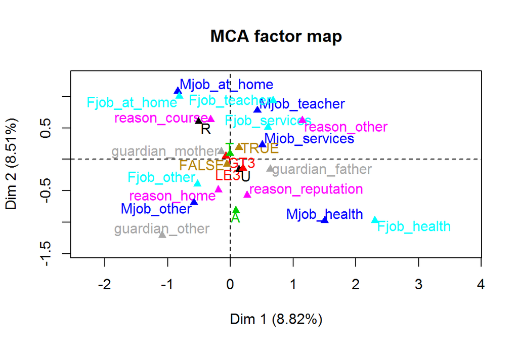

```r
plot(alc_mca, invisible=c("ind"), habillage = "quali")
```

The MCA biplot shows how similar the variables are with each other.It seems that ‘low use of alcohol’, ‘great than three family size’, ‘living together’ and guardian by mother’ are very similar.